# Instacart Cart Analysis EDA

# Introduction

In 2017, Instacart provided anonymized data on Kaggle describing customers’ orders over time.

The dataset contains a sample of over 3 million grocery orders from more than 200,000 Instacart users. For each user, Instacart provided between 4 and 100 of their orders, with the sequence of products purchased in each order. It also provided the week and hour of day the order was placed, and a relative measure of time between orders.

**Our objective is to predict which products will be in a user’s next order.**

# Load libraries

```r
library(tidyverse)
library(DataExplorer)
library(R.utils)
library(gridExtra)
library(ggridges)
library(treemap)
library(knitr)
library(plotly)
library(scales)
library(gridExtra)
library(RColorBrewer)
library(corrplot)
library(knitr)
library(kableExtra)
library(magrittr)
```

# Load data

```r
aisles <- read.csv("data/aisles.csv")
departments <- read.csv("data/departments.csv")
order_products_prior <- read.csv("data/order_products__prior.csv")
order_products_train <- read.csv("data/order_products__train.csv")
orders <- read.csv("data/orders.csv")
products <- read.csv("data/products.csv")
```

# Understanding the data

The dataset consists of information about 3.4 million grocery orders, distributed across 6 csv files. In this section, we focus on getting a good preliminary understanding of our data before going into deeper analysis.

```r
data_list <- list(products, aisles, departments, order_products_prior, order_products_train, orders)
plot_str(data_list)
```

1. **Products**: Contains the names of the products with their corresponding product_id. Aisle and department IDs are also included.
2. **Aisles**: Contains the id and the names of the different aisles
3. **Departments**: Contains the id and the names of the different departments.
4. **Order_products_prior**: Contains product information (product_id) and user order information such as add to cart order, and whether the product was reordered.
5. **Order_products_train**: Structure is similar to **Order_products_prior**, but information only about each order that is used for training.
6. **Orders**: List of all orders in the dataset, with 1 row per order. Each order is classified as prior, train, test. For example, user 1 has 11 orders - 10 classified as prior, and the last 1 as train. No product information is included.

## Understanding **Orders** table

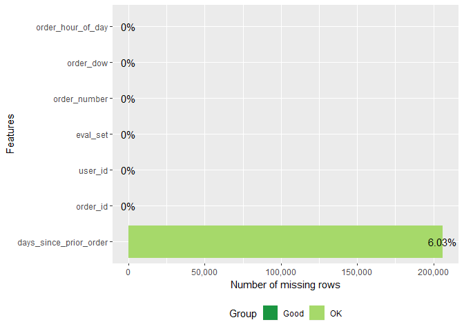

```r
plot_missing(orders)
```

- 6% of the days_since_prior_order are missing. This is due to customers not having a prior order before their first order. Hence, we will change the NAs to 0 in when we reshape the data.

```r
kable(count(orders,eval_set)) %>%
   kable_styling(bootstrap_options = c("striped", "hover", full_width = F, position = "left"))
```

| eval_set | n |
| --- | --- |
| prior | 3214874 |
| test | 75000 |
| train | 131209 |

- There is a total of 3.2 million distinct orders which captured as “prior”, which can be matched to the data in **order_products_prior**.
- 131,209 orders captured as “train” can be matched to the data in **order_products_train**.
- Our task is to predict the products found in the 75,000 orders captured as “test”.
- **As the train set only includes the last order number of a small amount of customers, we will use the data captured as “prior” to perform our EDA.**

## Reconfigure tables

### Product table

- To keep our data frame concise, we will remove aisle and department IDs.

```r
# set aisle and department names as factors
aisles %>% mutate(aisle = as.factor(aisle))
```

```
##     aisle_id                         aisle
## 1          1         prepared soups salads
## 2          2             specialty cheeses
## 3          3           energy granola bars
## 4          4                 instant foods
## 5          5    marinades meat preparation
## 6          6                         other
## 7          7                 packaged meat
## 8          8               bakery desserts
## 9          9                   pasta sauce
## 10        10              kitchen supplies
## 11        11              cold flu allergy
## 12        12                   fresh pasta
## 13        13                prepared meals
## 14        14        tofu meat alternatives
```

[output cut: 120 more lines]

```r
departments %>%  mutate(department = as.factor(department))
```

```
##    department_id      department
## 1              1          frozen
## 2              2           other
## 3              3          bakery
## 4              4         produce
## 5              5         alcohol
## 6              6   international
## 7              7       beverages
## 8              8            pets
## 9              9 dry goods pasta
## 10            10            bulk
## 11            11   personal care
## 12            12    meat seafood
## 13            13          pantry
## 14            14       breakfast
## 15            15    canned goods
## 16            16      dairy eggs
## 17            17       household
## 18            18          babies
## 19            19          snacks
## 20            20            deli
## 21            21         missing
```

```r
products_detail <- products %>%
  inner_join(aisles, by = "aisle_id") %>%
  inner_join(departments, by = "department_id") %>%

  # remove aisle and department ID
  select(-aisle_id, -department_id)

head(products_detail,10)
```

```
##    product_id
## 1           1
## 2           2
## 3           3
## 4           4
## 5           5
## 6           6
## 7           7
## 8           8
## 9           9
## 10         10
##                                                         product_name
## 1                                         Chocolate Sandwich Cookies
## 2                                                   All-Seasons Salt
## 3                               Robust Golden Unsweetened Oolong Tea
```

[output cut: 18 more lines]

- For the purpose of our EDA, we create a similar table that only captures “prior” orders.

```r
orders_prior_detail_eda <- products_detail %>%
  inner_join(order_products_prior, by = "product_id") %>%
  inner_join(orders, by = "order_id") %>%
  filter(eval_set == "prior")

head(orders_prior_detail_eda,10)
```

```
##    product_id               product_name         aisle department order_id
## 1           1 Chocolate Sandwich Cookies cookies cakes     snacks     1107
## 2           1 Chocolate Sandwich Cookies cookies cakes     snacks     5319
## 3           1 Chocolate Sandwich Cookies cookies cakes     snacks     7540
## 4           1 Chocolate Sandwich Cookies cookies cakes     snacks     9228
## 5           1 Chocolate Sandwich Cookies cookies cakes     snacks     9273
## 6           1 Chocolate Sandwich Cookies cookies cakes     snacks     9696
## 7           1 Chocolate Sandwich Cookies cookies cakes     snacks    11140
## 8           1 Chocolate Sandwich Cookies cookies cakes     snacks    11485
## 9           1 Chocolate Sandwich Cookies cookies cakes     snacks    12672
## 10          1 Chocolate Sandwich Cookies cookies cakes     snacks    13668
##    add_to_cart_order reordered user_id eval_set order_number order_dow
## 1                  7         0   38259    prior            2         1
## 2                  3         1  196224    prior           65         1
## 3                  4         1  138499    prior            8         0
```

[output cut: 18 more lines]

# Exploratory data analysis

In this section, we will attempt to derive insights about the customer orders on two levels:

- **Product-level**: Characteristics of a product
- **User-level**: Characteristics of a user

## Product-level insights

### How many unique products are offered in each aisle / department?

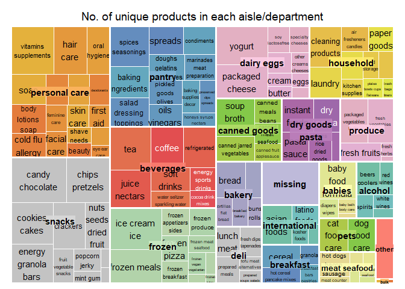

```r
product_portfolio <- products_detail %>%
  na.omit() %>%
  group_by(department, aisle) %>%
  summarise(n=n())

treemap(product_portfolio,
        index=c("department","aisle"),
        vSize="n",
        title="No. of unique products in each aisle/department",
        palette="Set3",
        border.col="#FFFFFF")
```

- We see a fairly well-represented number of products in each aisle and department, with personal care and snacks departments having the most unique products.

### Which are the more popular aisles and departments?

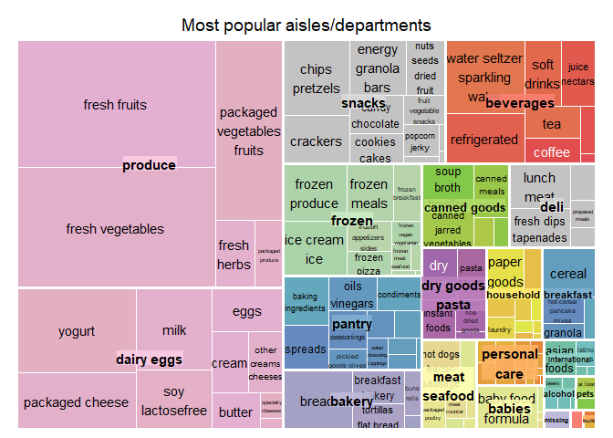

```r
products_sold <- orders_prior_detail_eda %>%
      na.omit() %>%
      group_by(department, aisle) %>%
      summarize(n=n()) %>%

treemap(products_sold,
        index=c("department","aisle"),
        vSize="n",
        title="Most popular aisles/departments",
        palette="Set3",
        border.col="#FFFFFF")
```

- Despite having a smaller variety, produce and dairy/eggs departments represent the highest quantity sold. This is expected as the goods in these departments are largely homogenous - Instacart will not stock too many brands and unique products.
- At the same time. this is representative of Instacart’s competitive advantage - groceries that generate consistent recurring spend.

### Which are our bestsellers?

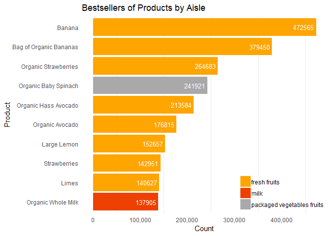

```r
my_palette <- c('orange', 'orangered2', 'darkgrey', "lightcoral")
my_theme <- theme_bw() + theme(axis.text.x = element_text(angle = 90, vjust = 0.5))

top_10_products <- orders_prior_detail_eda %>%
  group_by(product_name,aisle) %>%
  summarize(count=n()) %>%
  arrange(desc(count)) %>%
  head(n=10)


  ggplot(top_10_products,aes(x = reorder(product_name,count),y=count, fill=aisle)) +
    theme_minimal() +
    geom_bar(stat = "identity",color = FALSE)+
    xlab("Product")+ ylab("Count")+
    ggtitle("Bestsellers of Products by Aisle")+
    scale_fill_manual(values = my_palette) +
    geom_text(aes(label= count), hjust=1.1, colour='white', size=3.5) +
    coord_flip() +
    theme(panel.grid.major = element_blank(),
          legend.justification=c(1,0),
          legend.position=c(1,0),
          legend.title=element_blank()) +
    scale_y_continuous(labels = scales::comma)
```

- Out of the top 10 bestsellers, 8 are from the fresh fruits aisle.
- Bananas and avocados have two entries each in the top 10 bestseller list (organic and non-organic).

### Which departments do customers reorder from more frequently?

*First, we create the normalised quantity to facilitate comparison between deparments:*

```r
dpt_reorder <- orders_prior_detail_eda %>%
  group_by(department,days_since_prior_order) %>%

  # remove missing department
  filter(!department == "missing") %>%

  # remove 30 since it will distort normalisation - all reorders above 30 days are also captured in this column
  filter(!days_since_prior_order == 30) %>%

  # quantity reordered per department and days since prior order
  summarise(quantity = n()) %>%

  # create normalised feature (q-mean(q) / max(q)-min(q)) per dept to facilitate comparison between departments
  mutate(nor1 = quantity-mean(quantity), nor2 = max(quantity)-min(quantity), nor3= nor1 / nor2)

kable(head(dpt_reorder,10)) %>%
    kable_styling(bootstrap_options = c("striped", "hover", "condensed", "responsive"))
```

| department | days_since_prior_order | quantity | nor1 | nor2 | nor3 |
| --- | --- | --- | --- | --- | --- |
| alcohol | 0 | 4594 | 342.3 | 11593 | 0.0295264 |
| alcohol | 1 | 9125 | 4873.3 | 11593 | 0.4203657 |
| alcohol | 2 | 10453 | 6201.3 | 11593 | 0.5349176 |
| alcohol | 3 | 10375 | 6123.3 | 11593 | 0.5281894 |
| alcohol | 4 | 9887 | 5635.3 | 11593 | 0.4860951 |
| alcohol | 5 | 8820 | 4568.3 | 11593 | 0.3940568 |
| alcohol | 6 | 10025 | 5773.3 | 11593 | 0.4979988 |
| alcohol | 7 | 12396 | 8144.3 | 11593 | 0.7025188 |
| alcohol | 8 | 6951 | 2699.3 | 11593 | 0.2328388 |
| alcohol | 9 | 4792 | 540.3 | 11593 | 0.0466057 |

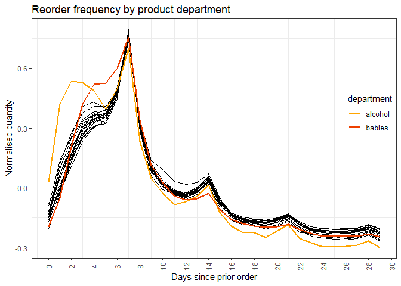

```r
# highlight babies and alcohol department
dpt_reorder_filtered <- dpt_reorder %>%
  filter(department=="babies" | department=="alcohol")

dpt_reorder_freq <- ggplot()+
  geom_line(data=dpt_reorder, aes(days_since_prior_order, nor3, group=department)) +
  geom_line(data=dpt_reorder_filtered, aes(days_since_prior_order, nor3, colour=department), size = 1) +
  theme_minimal() +
  xlab("Days since prior order")+ ylab("Normalised quantity")+ ggtitle("Reorder frequency by product department")+
  scale_color_manual(values = my_palette) +
  my_theme+
    theme(panel.grid.major = element_blank(),
          legend.justification=c(1,0),
          legend.position=c(1,0.5)) +
    scale_x_continuous(breaks = scales::pretty_breaks(15))

 dpt_reorder_freq
```

- In general, we see peaks in reorders every 7 days i.e. customers tend to order in weekly, bi-weekly or tri-weekly intervals.
- Most customers order once every 7 days.
- Interestingly, alcohol department has the highest normalized quantity of purchases that are reordered within the 0-3 day range, while Babies department has the highest within the 4-6 day range.
- However, after the first 7 days, alcohol has the lowest normalized quantity of purchases amongst all departments.

### Which bestsellers do customers reorder more frequently?

```r
prod_reorder <- orders_prior_detail_eda %>%
  group_by(product_name,days_since_prior_order) %>%

  # filter for only top 10 products
  filter(product_name %in% top_10_products$product_name) %>%

  # remove 30 since it will distort normalisation - all reorders above 30 days are also captured in this column
  filter(!days_since_prior_order == 30) %>%

  # quantity reordered per product and days since prior order
  summarise(quantity = n()) %>%

  # create normalised feature (q-mean(q) / max(q)-min(q)) per prod to facilitate comparison between products
  mutate(nor1 = quantity-mean(quantity), nor2 = max(quantity)-min(quantity), nor3= nor1 / nor2)

kable(head(prod_reorder,10)) %>%
    kable_styling(bootstrap_options = c("striped", "hover", "condensed", "responsive"))
```

| product_name | days_since_prior_order | quantity | nor1 | nor2 | nor3 |
| --- | --- | --- | --- | --- | --- |
| Bag of Organic Bananas | 0 | 4689 | -6379.533 | 41149 | -0.1550350 |
| Bag of Organic Bananas | 1 | 9860 | -1208.533 | 41149 | -0.0293697 |
| Bag of Organic Bananas | 2 | 19568 | 8499.467 | 41149 | 0.2065534 |
| Bag of Organic Bananas | 3 | 27574 | 16505.467 | 41149 | 0.4011146 |
| Bag of Organic Bananas | 4 | 30565 | 19496.467 | 41149 | 0.4738017 |
| Bag of Organic Bananas | 5 | 29277 | 18208.467 | 41149 | 0.4425008 |
| Bag of Organic Bananas | 6 | 32530 | 21461.467 | 41149 | 0.5215550 |
| Bag of Organic Bananas | 7 | 42773 | 31704.467 | 41149 | 0.7704796 |
| Bag of Organic Bananas | 8 | 23300 | 12231.467 | 41149 | 0.2972482 |
| Bag of Organic Bananas | 9 | 14350 | 3281.467 | 41149 | 0.0797460 |

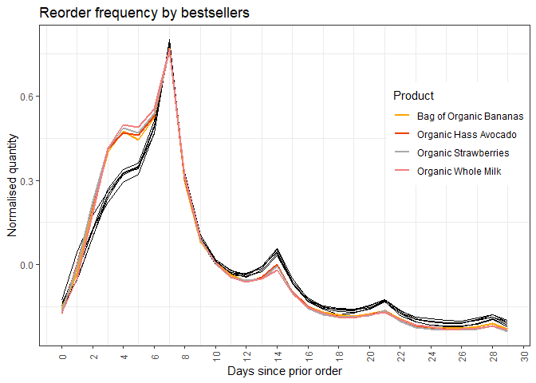

```r
# highlight products where normalised quantity is anomalous
prod_reorder_filtered <- prod_reorder %>%
  filter(product_name=="Organic Strawberries" | product_name=="Bag of Organic Bananas" | product_name=="Organic Whole Milk" | product_name=="Organic Hass Avocado")

prod_reorder_freq <- ggplot()+
  geom_line(data=prod_reorder, aes(days_since_prior_order, nor3, group=product_name)) +
  geom_line(data=prod_reorder_filtered, aes(days_since_prior_order, nor3, colour=product_name), size = 1) +
  theme_minimal() +
  xlab("Days since prior order")+ ylab("Normalised quantity")+ ggtitle("Reorder frequency by bestsellers")+ labs(colour = "Product") +
  scale_color_manual(values = my_palette) +
  my_theme+
    theme(panel.grid.major = element_blank(),
          legend.justification=c(1,0),
          legend.position=c(1,0.5)) +
    scale_x_continuous(breaks = scales::pretty_breaks(15))

prod_reorder_freq
```

- Similar to department reorder analysis above, we see peaks in reorders every 7 days i.e. customers tend to order in weekly, bi-weekly or tri-weekly intervals.
- Interestingly, even though there were only 6 organic products out of the top 10 bestsellers, all 4 bestsellers with the highest normalized quantity of purchases reordered within the 0-6 day range are **organic products**.
- *This prompts further analysis - do organic products get reordered more often than non-organic products?*

### Do organic products get reordered more frequently than non-organic products?

```r
# add new column in products to classify whether product is organic
products_organic <- products %>%
    mutate(organic=ifelse(str_detect(str_to_lower(products$product_name),'organic'),"organic","non-organic"), organic= as.factor(organic))

# joining tables
order_products_organic <- products_organic %>%
  inner_join(order_products_prior) %>%
  inner_join(orders)

# generate data frame for summarising organic vs days since prior order
organic_reorder <- order_products_organic %>%
    group_by(organic,days_since_prior_order) %>%

    # remove 30 since it will distort normalisation - all reorders above 30 days are also captured in this column
    filter(!days_since_prior_order == 30) %>%

    # quantity reordered per product and days since prior order
    summarise(quantity = n()) %>%

    # create normalised feature (q-mean(q) / max(q)-min(q)) per prod to facilitate comparison between products
    mutate(nor1 = quantity-mean(quantity), nor2 = max(quantity)-min(quantity), nor3= nor1 / nor2)
```

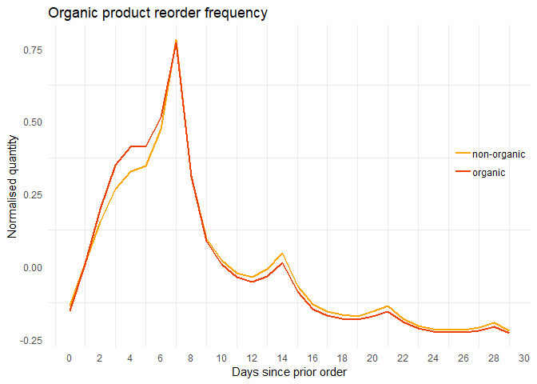

```r
organic_reorder_freq <- ggplot()+
  geom_line(data=organic_reorder, aes(days_since_prior_order, nor3, colour=organic), size =1) +
  theme_minimal() +
  xlab("Days since prior order")+ ylab("Normalised quantity")+ ggtitle("Organic product reorder frequency") +
    theme(panel.grid.major = element_blank(),
          legend.justification=c(1,0),
          legend.position=c(1,0.5),
          legend.title=element_blank()) +
  scale_color_manual(values = my_palette)+
    scale_x_continuous(breaks = scales::pretty_breaks(15))

organic_reorder_freq
```

- The trend we found in our earlier bestseller reorder frequency analysis can be extended to all organic products. Organic products display higher normalized quantity of purchases reordered within the 3-6 day range as compared to inorganic products.
- Customers who order organic products tend to place their orders more frequently than customers who do not

### Which products have the highest likelihood of being reordered?

```r
product_reorder_prob <- orders_prior_detail_eda %>%
  arrange(user_id, order_number, product_id) %>%

  # group so that we can count user_id-product_name occurrences
  group_by(user_id, product_name) %>%

  # row number is our count of the number of occurrences
  mutate(ordered_times = row_number()) %>%

  # ungroup for regrouping later
  ungroup() %>%

  # now we regroup by product name and department (for plotting)
  group_by(product_name, department) %>%

  # get product level reorder probability = number of reorders / number of orders
  summarise(number_of_orders = n(),
            number_of_reorders = sum(reordered),
            reorder_probability = number_of_reorders / number_of_orders)
```

```r
# get top 20 products ranked by reorder probability
top20_reorder_prob <- product_reorder_prob %>%
  arrange(desc(reorder_probability)) %>%
  head(n=20)

# get top 20 bestsellers' reorder probability
bestseller_reorder_prob <- product_reorder_prob %>%
  arrange(desc(number_of_orders)) %>%
  head(n=20)

top20_reorder_prob
```

```
## # A tibble: 20 x 5
## # Groups:   product_name [20]
##    product_name department number_of_orders number_of_reord~
##    <fct>        <fct>                 <int>            <int>
##  1 Raw Veggie ~ deli                     68               64
##  2 Serenity Ul~ personal ~               87               81
##  3 Orange Ener~ beverages                13               12
##  4 Chocolate L~ snacks                  101               93
##  5 Soy Powder ~ babies                   35               32
##  6 Simply Slee~ other                    45               41
##  7 Energy Shot~ beverages                22               20
##  8 Maca Butter~ snacks                  100               90
##  9 Russian Riv~ alcohol                  30               27
## 10 Sparking Wa~ beverages                60               54
## 11 Bars Peanut~ pantry                   67               60
## 12 Soy Crisps ~ snacks                   66               59
## 13 Jet Fuel Da~ beverages                28               25
## 14 Benchbreak ~ alcohol                 111               99
## 15 High Gravit~ alcohol                  37               33
## 16 Almond Orge~ pantry                   27               24
## 17 Buttery Spr~ missing                  18               16
## 18 Organic Blu~ beverages                96               85
## 19 Beer Can     alcohol                  52               46
## 20 Amazake Alm~ beverages                25               22
## # ... with 1 more variable: reorder_probability <dbl>
```

```r
bestseller_reorder_prob
```

```
## # A tibble: 20 x 5
## # Groups:   product_name [20]
##    product_name department number_of_orders number_of_reord~
##    <fct>        <fct>                 <int>            <int>
##  1 Banana       produce              472565           398609
##  2 Bag of Orga~ produce              379450           315913
##  3 Organic Str~ produce              264683           205845
##  4 Organic Bab~ produce              241921           186884
##  5 Organic Has~ produce              213584           170131
##  6 Organic Avo~ produce              176815           134044
##  7 Large Lemon  produce              152657           106255
##  8 Strawberries produce              142951            99802
##  9 Limes        produce              140627            95768
## 10 Organic Who~ dairy eggs           137905           114510
## 11 Organic Ras~ produce              137057           105409
## 12 Organic Yel~ produce              113426            79072
## 13 Organic Gar~ produce              109778            74663
## 14 Organic Zuc~ produce              104823            72165
## 15 Organic Blu~ produce              100060            62922
## 16 Cucumber Ki~ produce               97315            67313
## 17 Organic Fuj~ produce               89632            63811
## 18 Organic Lem~ produce               87746            60536
## 19 Apple Honey~ produce               85020            62510
## 20 Organic Gra~ produce               84255            55230
## # ... with 1 more variable: reorder_probability <dbl>
```

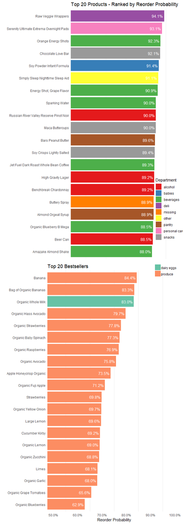

```r
# plot top 20 products ranked by reorder probability
bar1 <- ggplot(top20_reorder_prob, aes(reorder(product_name,reorder_probability), reorder_probability, fill=department)) +
    theme_minimal() +
    geom_bar(stat = "identity")+
    xlab("")+ ylab("") + labs(fill = "Department") + ggtitle("Top 20 Products - Ranked by Reorder Probability") +
    geom_text(aes(label= sprintf("%1.1f%%", reorder_probability*100)), hjust=1.1, colour='white') +
    coord_flip(ylim = c(0.5,1)) +
    theme(panel.grid.major = element_blank(),
          legend.position=c(0.9,0.2),
          # legend.title = element_text(size = 30, face="bold"),
          # legend.text = element_text(size = 30),
          # plot.title=element_text(size = 40, face="bold"),
          # axis.text.y=element_text(size = 18),
          # axis.title.y=element_text(size=10),
          axis.text.x=element_blank(),
          axis.title.x=element_blank(),
          axis.ticks.x = element_blank())+
          scale_fill_brewer(palette="Set1") +
         scale_y_continuous(labels = scales::percent)

# plot top 20 bestsellers' reorder probability
bar2 <- ggplot(bestseller_reorder_prob, aes(reorder(product_name,reorder_probability), reorder_probability, fill=department)) +
    theme_minimal() +
    geom_bar(stat = "identity")+
    xlab("")+ ylab("Reorder Probability") + ggtitle("Top 20 Bestsellers")+
    geom_text(aes(label= sprintf("%1.1f%%", reorder_probability*100)), hjust=1.1, colour='white') +
    coord_flip(ylim = c(0.5,1)) +
    theme(panel.grid.major = element_blank(),
          legend.title = element_blank(),
          legend.position = c(0.885,1)) +
          # legend.text = element_text(size = 30),
          # plot.title=element_text(size = 40, face="bold"),
          # axis.text.y=element_text(size = 30),
          # axis.text.x=element_text(size = 30),
          # axis.title.y=element_text(size=10),
          # axis.title.x=element_text(size=30)
    scale_fill_brewer(palette="Set2") +
    scale_y_continuous(labels = scales::percent)

    grid.arrange(bar1, bar2,nrow=2)
```

### Which time of the day does each department sell the most?

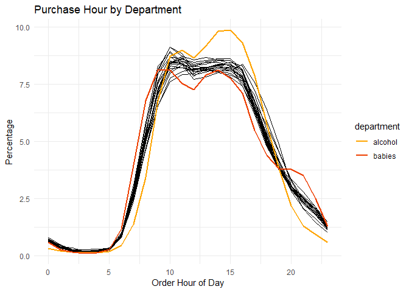

```r
department_hod <- orders_prior_detail_eda %>%
  group_by(department,order_hour_of_day) %>%
  summarize(count = n()) %>%
  mutate(department_sum = sum(count),percent = 100*count/sum(count))

department_hod_special <- orders_prior_detail_eda %>%
  filter(department == "alcohol"| department == "babies") %>%
  group_by(department,order_hour_of_day) %>%
  summarize(count = n()) %>%
  mutate(department_sum = sum(count),percent = 100*count/sum(count))

department_hod %>%
  ggplot() +
  ggtitle("Purchase Hour by Department")+
  xlab("Order Hour of Day")+
  ylab("Percentage")+
  geom_line(data = department_hod,aes(x = order_hour_of_day,y=percent,group = department))+
  geom_line(data = department_hod_special, aes(x = order_hour_of_day,y=percent,color = department),size=1)+
  scale_color_manual(values = my_palette) +
  my_theme+
  theme_minimal()
```

- As compared to the other departments, alcohol sells the best in the afternoon!
- The babies department has a significant dip during lunch hours, and picks up later in the evening. Is this the time when most babies are finally asleep?

### What products do users order at different hours of the day?

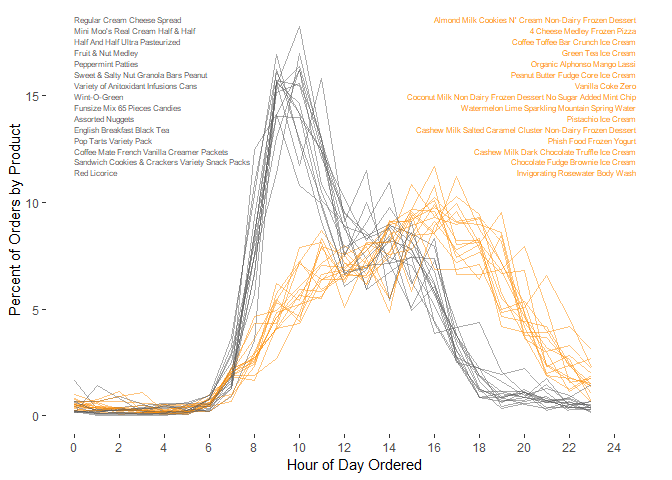

```r
Mode <- function(x) {
  ux <- unique(x)
  ux[which.max(tabulate(match(x, ux)))]
}

#number of orders by products
order_by_hour <- orders_prior_detail_eda %>%
  group_by(product_name,order_hour_of_day) %>%
  summarise(count = n_distinct(order_id))

#get statistics of each product
products_by_order <- orders_prior_detail_eda %>%
  group_by(product_name) %>%
  summarise(totalCount = n_distinct(order_id), mean_time = mean(order_hour_of_day), mode = Mode(order_hour_of_day)) %>%
  filter(totalCount>360) %>%
  arrange(desc(totalCount)) %>%
  slice(1:15000)

#categorize morning and afternoon products and select top 25
afternoon_products <- products_by_order %>%
  filter(mean_time >12 & mean_time <23, mode >= 15 & mode<= 17) %>%
  arrange(desc(mean_time)) %>%
  slice(1:15)

morning_products <- products_by_order %>%
  filter(mean_time >0 & mean_time <12, mode>=9 & mode <= 11) %>%
  arrange(mean_time) %>%
  slice(1:15)

morning_names <- morning_products %$% paste(product_name, collapse = '\n')
afternoon_names <- afternoon_products %$% paste(product_name, collapse = '\n')

#calculate percentage of orders by products at each hour
afternoon_products_detail <- afternoon_products %>%
  left_join(order_by_hour, by = "product_name") %>%
  mutate(pct = 100*count/totalCount) %>%
  arrange(desc(mean_time)) %>%
  select(-totalCount,-mean_time,-mode,-count) %>%
  mutate(hour_group = "afternoon")

morning_products_detail <- morning_products %>%
  left_join(order_by_hour, by = "product_name") %>%
  mutate(pct = 100*count/totalCount) %>%
  arrange(mean_time) %>%
  select(-totalCount,-mean_time,-mode,-count) %>%
  mutate(hour_group = "morning")

#combine the morning and afternoon tables
products_hour_detail = rbind(afternoon_products_detail,morning_products_detail)

#graphing
products_hour_detail %>%
  ggplot(aes(x = order_hour_of_day, y = pct, group = product_name,colour = hour_group)) +
  geom_line(alpha = .5)+
  labs(x = "Hour of Day Ordered", y = "Percent of Orders by Product") +
    theme(legend.position = 'none') +
    scale_colour_manual(values = c("darkorange", "gray35")) +
    theme(panel.background = element_blank()) +
    scale_x_continuous(breaks = seq(0, 24, by = 2))+
  annotate("text", x = 0, y = 15, label = morning_names, adj = 0, size = 2, colour = "gray35") +
  annotate("text", x = 25, y = 15, label = afternoon_names, adj = 1, size = 2, colour = "darkorange")
```

- In the morning, most of the top products that people shop are breakfast, snacks and coffee related.
- During the afternoon, surprisingly, 10 out of the top 15 products purchased are ice cream products.

## User-level insights

In the dataset provided, Instacart has 206209 unique customers.

### How many orders did each user place?

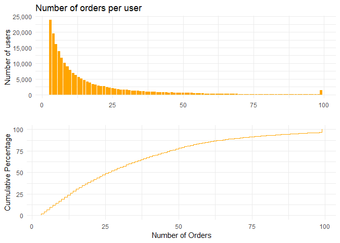

```r
ord1 <- orders_prior_detail_eda %>%
  group_by(user_id) %>%
  summarize(order_number = max(order_number))

plot1 <- ggplot(ord1, aes(x = order_number)) +
  ggtitle("Number of orders per user")+
  xlab("")+
  ylab("Number of users")+
  geom_bar(fill = "orange")+
  theme_minimal()+
  scale_y_continuous(labels = scales::comma)

ord2 <- orders_prior_detail_eda %>%
  group_by(user_id) %>%
  summarize(order_number = max(order_number), count = n()) %>%
  arrange(order_number) %>%
  mutate(pct = 100*count/sum(count), cum_pct = cumsum(pct))

plot2 <- ggplot(ord2, aes(x = order_number,y = cum_pct)) +
  xlab("Number of Orders")+
  ylab("Cumulative Percentage")+
  geom_line(color = "orange",stat = "identity")+
  theme_minimal()+
  scale_y_continuous(labels = scales::comma)

  grid.arrange(plot1, plot2, nrow=2)
```

- As explained by Instacart, the dataset contains maximum of 100 orders for each user. For any user who placed above 100 orders, she will still be classified as having only 100 orders, explaining the anomaly in the chart above at the 100th order mark in the top chart.
- Looking at the cumulative percentage, 50% of users in our dataset placed more than 25 orders, while 25% placed less than 13 orders.

### How often do users place an order?

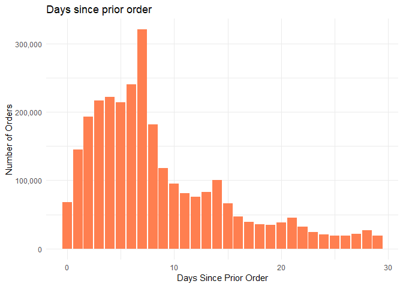

```r
order_lapse <- orders %>%
  group_by(days_since_prior_order) %>%
  summarize(count = n()) %>%
  # remove 30 since it will distort data since all reorders above 30 days are also captured in this column
  filter(!days_since_prior_order == 30)

ggplot(order_lapse,aes(days_since_prior_order,count))+
  theme_minimal()+
  xlab("Days Since Prior Order")+
  ylab("Number of Orders")+
  ggtitle("Days since prior order")+
  geom_bar(stat = "identity",na.rm = TRUE,fill = "coral")+
  scale_y_continuous(labels = scales::comma)
```

- Interestingly, most users place an order between 7 days after their previous order. This reflects a behaviour that people usually shop on a weekly basis.
- There are also smaller peaks on days 14, 21 and 28. It could be possible that some users like to shop once every 2 or 3 weeks as well.

### Is the number of orders related to the users’ shopping frequency?

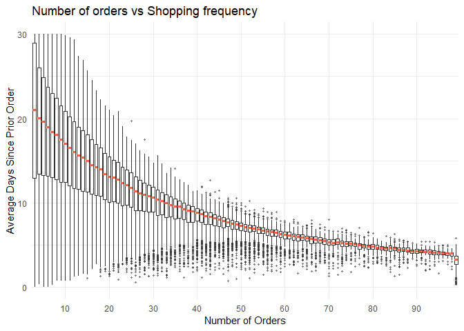

```r
orders_prior_detail_boxplot <- orders_prior_detail_eda %>%
  group_by(user_id) %>%
  summarise(shopping_frequency = mean(days_since_prior_order,na.rm = TRUE),order_number = max(order_number)) %>%
  mutate(order_number = as.factor(order_number)) %>%
  ggplot(aes(x = order_number, y = shopping_frequency)) +
  ggtitle("Number of orders vs Shopping frequency")+
  xlab("Number of Orders")+
  ylab("Average Days Since Prior Order")+
  geom_boxplot(outlier.size = 0.8, outlier.alpha = 0.5)+
  scale_x_discrete(breaks = scales::pretty_breaks(10))+
  theme_minimal()

dat <- ggplot_build(orders_prior_detail_boxplot)$data[[1]]

orders_prior_detail_boxplot + geom_segment(data=dat, aes(x=xmin, xend=xmax,
                               y=middle, yend=middle), colour="tomato", size=1.2)
```

- As seen in the chart above, The mean number of days since prior order decreases with the number of orders that a user places. Users who placed more orders tend to shop at higher frequencies, placing an order once every 4-10 days.

### Do customers place their orders at a certain time?

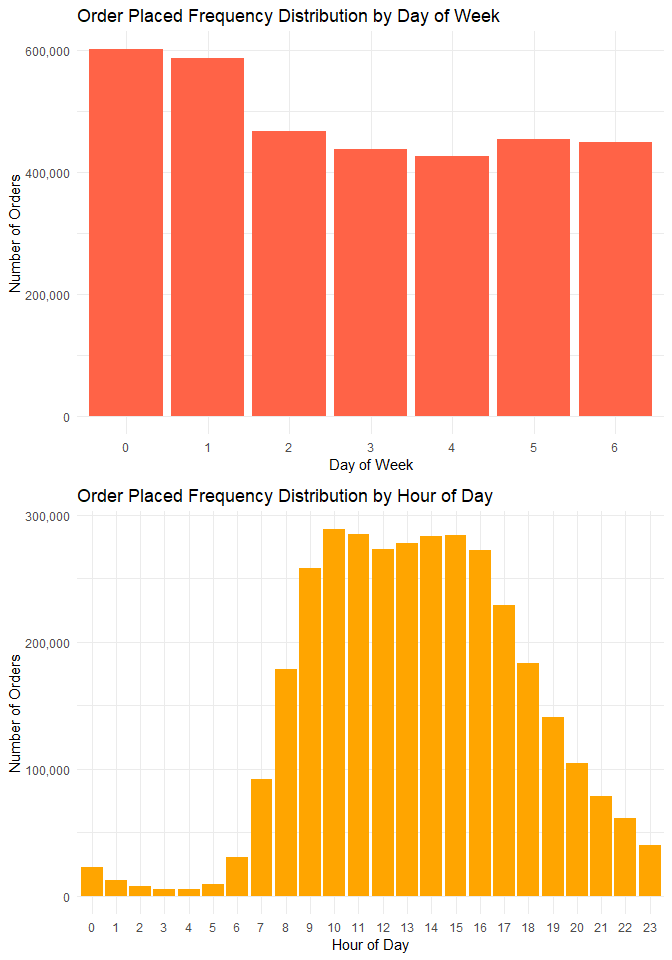

```r
orders_dow <- orders %>%
  mutate(order_dow = as.factor(order_dow)) %>%
  group_by(order_dow) %>%
  summarize(count = n())

time1 <- ggplot(orders_dow,aes(order_dow,count))+
  theme_minimal()+
  xlab("Day of Week")+
  ylab("Number of Orders")+
  ggtitle("Order Placed Frequency Distribution by Day of Week")+
  geom_bar(stat = "identity", fill = "tomato")+
  scale_y_continuous(labels = scales::comma)

orders_time <- orders %>%
  mutate(order_hour_of_day = as.factor(order_hour_of_day)) %>%
  group_by(order_hour_of_day) %>%
  summarize(count = n())

time2 <- ggplot(orders_time,aes(order_hour_of_day,count))+
  theme_minimal()+
  xlab("Hour of Day")+
  ylab("Number of Orders")+
  ggtitle("Order Placed Frequency Distribution by Hour of Day")+
  geom_bar(stat = "identity",fill = "orange")+
  scale_y_continuous(labels = scales::comma)

grid.arrange(time1, time2, nrow=2)
```

- Customers shop the most on Sunday with a decreasing trend through the week; order number starts to pick on Friday
- The number of orders increase significantly each day from 7am and peaks at 10am. There is a slight decrease during the lunch hours at 12pm, before increasing slighting at 2-3pm. People actually shop the most during working hours!
- Putting the two distributions together:

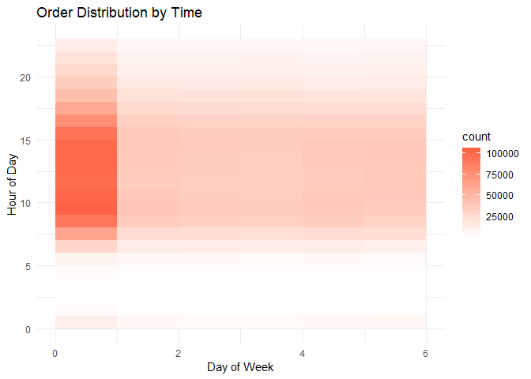

```r
  ggplot(orders, aes(x = order_dow,y=order_hour_of_day))+
  geom_bin2d(binwidth = c(1,1))+
  ggtitle("Order Distribution by Time")+
  xlab("Day of Week")+
  ylab("Hour of Day")+
  scale_fill_gradient2(low="yellow", high="tomato")+
  theme_minimal()
```

- We can see that the most popular time to place orders is on Sunday late morning to early afternoon.